# Estimating the money demand for Brazil

A. Schmidt

August, 2018

# Loading packages

This chunk verifies if the required packages are installed and loads them in the current R session. When some of the packages are not installed, they will be downloaded, installed and loaded. If mirror 10 (UFRJ) is offline, try to change `ind = 10` to `ind = 1`.

```r
chooseCRANmirror(graphics = FALSE, ind = 10)
if (!require("pacman")) install.packages("pacman")
pacman::p_load(ggplot2, BETS, stargazer, gridExtra, reshape2, RColorBrewer, scales, zoo, readxl, gtable, magrittr,  knitr, grid, ggpubr, gdata, urca, kableExtra, knitr, readxl, seasonal, forecast, het.test, lubridate, coda)
```

# M1 and the monetary base

The data is available at the [Sistema Gerenciador de Séries Temporais (SGS) do Banco Central](https://www3.bcb.gov.br/sgspub/localizarseries/localizarSeries.do?method=prepararTelaLocalizarSeries).

We are going to use the average of the period, for both monetary base as well as M1. As deflator, we are going to use the last available IPCA index. The R package used to download the data directly from the Central Bank is called `BETS`.

```r
# Algumas variáveis auxiliares de datas, assim não precisamos alterar o código inteiro depois
# Eu recomendo sempre usar uma data de fim única, pois algumas variáveis demoram mais para ser atualizadas do que outras
inicio_82 <- "1982-01-01"
inicio_95 <- "1995-01-01" # Estou usando isso para cortar as séries posteriormente
inicio_96 <- "1996-01-01"
fim       <- "2018-06-30"
ano <- as.numeric(substr(inicio_82, start = 1, stop = 4))
mes <- as.numeric(substr(inicio_82, start = 6, stop = 7))
dia <- as.numeric(substr(inicio_82, start = 9, stop = 10))

M1   <- BETS.get("1824", from = inicio_82, to = fim)
BM   <- BETS.get("1785", from = inicio_82, to = fim)
IPCA <- BETS.get("433",  from = inicio_82, to = fim)

# Agora preciso converter os valores de M1 e BM para reais
# Peguei aqui: http://diniznumismatica.blogspot.com.br/2017/10/converter-outros-padroes-monetarios-em.html
# Cruzeiro Novo (de 01/02/1967 até 28/02/1986)
# Faça a divisão por 1000^3 * 2750
M1_1 <- window(M1, c(1982,01), c(1986,02))/((1000^3)*2750)
BM_1 <- window(BM, c(1982,01), c(1986,02))/((1000^3)*2750)

# Cruzado (de 01/03/1986 até 31/01/1989)
# Faça a divisão por 1000^2 * 2750
M1_2 <- window(M1, c(1986,03), c(1989,01))/((1000^2)*2750)
BM_2 <- window(BM, c(1986,03), c(1989,01))/((1000^2)*2750)

# Cruzado Novo e Cruzeiro (01/02/1989 a 31/07/1993)
# Faça a divisão por 1000*2750
M1_3 <- window(M1, c(1989,02), c(1993,07))/(1000*2750)
BM_3 <- window(BM, c(1989,02), c(1993,07))/(1000*2750)

# Cruzeiro real (01/08/1993 a 30/06/1994)
# Faça a divisão por 2750
M1_4 <- window(M1, c(1993,08), c(1994,06))/(2750)
BM_4 <- window(BM, c(1993,08), c(1994,06))/(2750)

# Último pedaço - plano real
M1_5 <- window(M1, c(1994,07))
BM_5 <- window(BM, c(1994,07))

comb <- ts.union(M1_1, M1_2, M1_3, M1_4, M1_5)
M1_final <- pmin(comb[,1], comb[,2], comb[,3], comb[,4], comb[,5], na.rm = TRUE)

comb <- ts.union(BM_1, BM_2, BM_3, BM_4, BM_5)
BM_final <- pmin(comb[,1], comb[,2], comb[,3], comb[,4], comb[,5], na.rm = TRUE)

# Agora vou trabalhar com o deflator. Usei a metodologia do IPEA http://www.ipeadata.gov.br/iframe_transformacao.aspx?width=1474&height=701
ipca2 <- IPCA # Salvo em uma nova variável só pro caso de dar errado não ter que baixar os dados de novo
ipca2[1] <- 100 # Primeiro faço o primeiro valor ser a base e depois mudo de base porque eu aprendi assim

# Transforma em índice
for (i in 2:length(ipca2)){
  ipca2[i] <- round(ipca2[(i-1)]*(1+ipca2[(i)]/100),2)
}

# Média geométrica
for (i in 1:(length(ipca2)-1)){
  ipca2[i] <- sqrt(ipca2[i]*ipca2[(i+1)])
}

# Muda a base para o último valor
for (i in 1:length(ipca2)) {
  ipca2[i] <- tail(ipca2, n=1)/ipca2[i]
}

ipca2 <- ts(ipca2,  start = c(ano, mes, dia), frequency = 12) # Converte para série temporal

# Deflaciona M1 e BM
M1_def <- M1_final * ipca2
BM_def <- BM_final * ipca2
```

Now, to the graphs. First, we organize everything.

```r
# Criação de variáveis auxiliares
Data1 <- seq(as.Date(inicio_82), length = length(M1_def), by = "1 month")
M1_def2 <- window(M1_def, c(1995, 01))
Data2 <- seq(as.Date(inicio_95), length = length(M1_def2), by = "1 month")

df1 <- data.frame(Data1, M1_def/10^6)
names(df1) <- c("Data", "M1")
cores <- brewer.pal(6, "Dark2")

breakpoints_1 <- c("Fev 1986", "Jun 1987", "Jan 1989", "Mar 1990", "Fev 1991", "Mai 1991")
# Cada data entra separadamente
bp1 <- c(which(as.yearmon(time(M1_def)) == breakpoints_1[1]),
         which(as.yearmon(time(M1_def)) == breakpoints_1[2]),
         which(as.yearmon(time(M1_def)) == breakpoints_1[3]),
         which(as.yearmon(time(M1_def)) == breakpoints_1[4]),
         which(as.yearmon(time(M1_def)) == breakpoints_1[5]),
         which(as.yearmon(time(M1_def)) == breakpoints_1[6]))

p1 <- ggplot(df1, aes(Data))+
        geom_line(aes(y = M1), colour = cores[1]) +
        scale_x_date(date_breaks = "24 months", name = "Date", labels = date_format("%m-%Y"))+
        scale_y_continuous(name = "M1 (R$ Millions)")+
        theme_bw() + theme(axis.text.x = element_text(angle=30, hjust = 1, size = 7))+
        geom_vline(xintercept = Data1[bp1], linetype="longdash", size = 0.5, alpha = 0.35)+
        annotate("text", x = Data1[bp1][1], y = 400, label = paste0("Cruzado Plan \n Feb 86"), size = 2.5)+
        annotate("text", x = Data1[bp1][2], y = 350, label = paste0("Bresser Plan \n Jun 87"), size = 2.5)+
        annotate("text", x = Data1[bp1][3], y = 300, label = paste0("Summer Plan \n Jan 89"), size = 2.5) +
        annotate("text", x = Data1[bp1][4], y = 250, label = paste0("Collor 1 Plan \n Mar 90"), size = 2.5)+
        annotate("text", x = Data1[bp1][5], y = 200, label = paste0("Collor 2 Plan \n Jan 91"), size = 2.5)+
        annotate("text", x = Data1[bp1][6], y = 150, label = paste0("Marcílio Plan \n May 91"), size = 2.5)+
        labs(title = "M1", subtitle = "In BRL millions - Jun/18")

# Faz o gráfico de 95 em diante
df2 <- data.frame(Data2, M1_def2/10^6)
names(df2) <- c("Date", "M1")

# Calcula as posições datas para colocar linhas verticais
breakpoints_2 <- c("Jan 1997", "Jan 2008", "Jan 2003")
# Cada data entra separadamente
bp2 <- c(which(as.yearmon(time(M1_def2)) == breakpoints_2[1]),
         which(as.yearmon(time(M1_def2)) == breakpoints_2[2]),
         which(as.yearmon(time(M1_def2)) == breakpoints_2[3]))

p2 <- ggplot(df2, aes(Date))+
        geom_line(aes(y = M1), colour = cores[2]) +
        scale_x_date(date_breaks = "24 months", name = "Date", labels = date_format("%m-%Y"))+
        scale_y_continuous(name = "M1 (R$ Millions)")+
        theme_bw() + theme(axis.text.x = element_text(angle=30, hjust = 1, size = 10))+
        geom_vline(xintercept = Data2[bp2], linetype="longdash", size = 0.5, alpha = 0.35)+
        annotate("text", x = Data2[bp2][1]+10, y = 400, label = paste0("Begin of CPMF\n Jan 97"), size = 2.5)+
        annotate("text", x = Data2[bp2][2]+10, y = 400, label = paste0("End of CPMF\n Jan 08"), size = 2.5)+
        annotate("text", x = Data2[bp2][3]+10, y = 400, label = paste0("Lula takes office\n Jan 03"), size = 2.5)+
        labs(title = "M1", subtitle = "In BRL millions - Jun/18")
```

First graph starts in Jan/1995 (6 months after the currency stabilization). Since we are analyzing the currency demand, we a using the average series (the series measured in the end of the month is most suitable to analyze the public accounts, due to seigniorage).

The break observed in the graph, where it changes its behavior in 1997, is due to the creation of [CPMF](https://pt.wikipedia.org/wiki/Contribui%C3%A7%C3%A3o_Provis%C3%B3ria_sobre_Movimenta%C3%A7%C3%A3o_Financeira) (in Jan 23rd, 1997). Since this tax is over the cashdraws, people are going less to the bank or they are not going to make deposits at all. In 1999 it was extinct for 6 months (Jan-Jun) and was finally extinct in Jan/2008. With the CPMF ending, people started to reduce their cash retention.

As for Jan/2003, there was a raise in the interest rate to counter the raise in the exchange rate, which ocurred in response to the new elected president. Remember: when interest rates go up, the demand for money goes down.

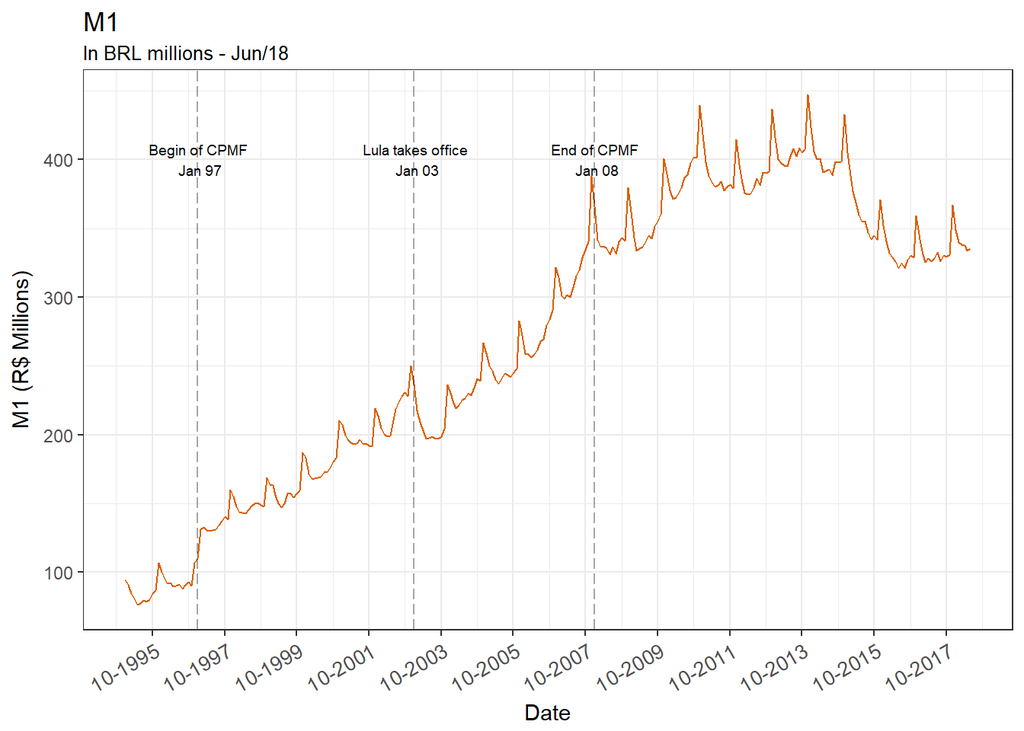

In this next graph we have the whole period. In 1994 with the implementation of the Plano Real we have a an abrupt increase in the demand for money, pushed by the economy stabilization.

From Jan/82 to 1986 we had the hyperinflation period, which, throught the Fisher channel, increased the interest rate: people spent all their money in the beginning of the month and didn’t demand money. The two other lines after 86 are the Plano Bresse and Plano Verão.

Also in 1986, there was the Plano Cruzado, where a change in the multiplier made things strange. Prices were frozen in February, impacting the economy. The financial application return dropped from 20% to 0.6% per month. Knowing about the decrease in interest rates, people started to demand money, which increased the PMPP and deposits in cash. People who received money simply didn’t deposited in the bank, because the return was ridiculous and people whose money was in the bank didn’t bother to change to another financial applications. With all this money available, banks started to increase credit supply by further diminishing the interest rates. This led to a increase in the money supply in the economy, which, by its turn, increased consumption (aggregate demand increased). The productive capacity stayed the same, but they couldn’t raise prices (they were frozen!), leading tp scarcity. This would be prevented with the central bank had raised the compulsory transfers from the commercial banks (in fact, this was one of the policies in the implementarion of the Real currency in 1994).

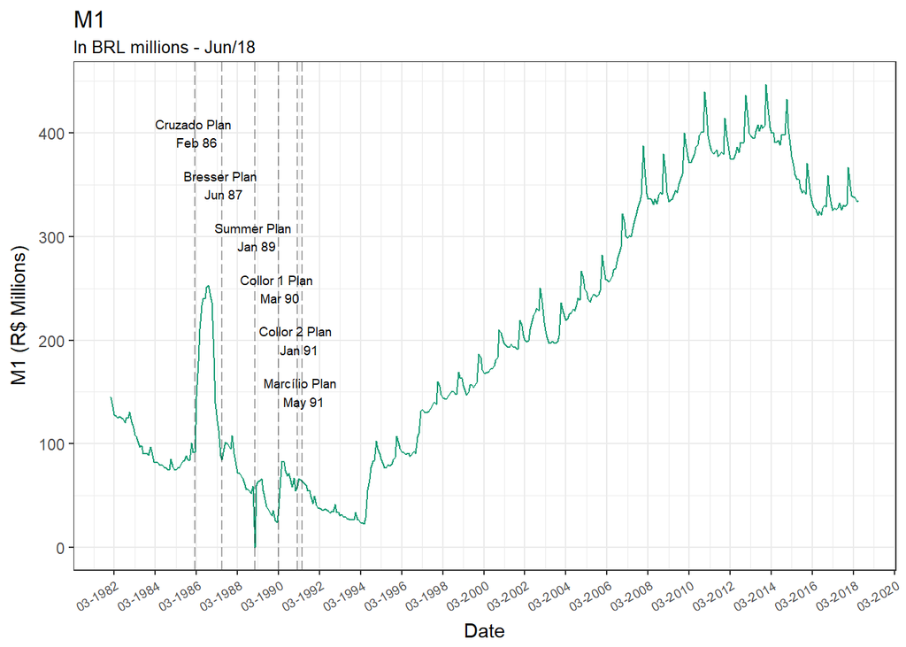

## Money multiplier

Now we are going to take a look into the money multiplier, given by `M1/BM`. In 1994, to avoid an increase in the multiplier motivated by the lower inflation, the Central Bank altered the compulsory deposits, making the multiplier shrink. As for 2002, due to the uncertainty in the elections, it was necessary to raise the interest rates (contractionary policy to counter inflation).

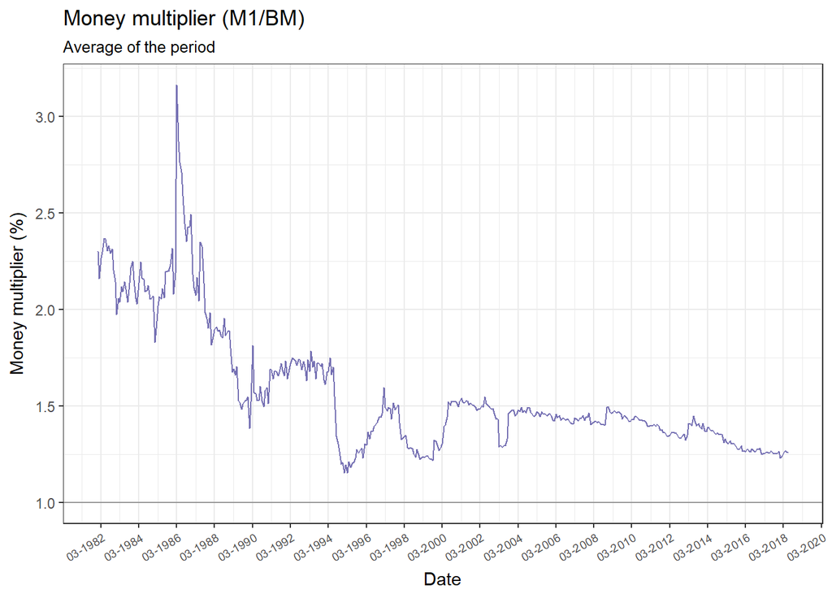

## Compulsory deposits

The original series is not available for direct download. Therefore, I used the spreadsheet available on the [Central Bank’s wepage](https://www.bcb.gov.br/htms/infecon/seriehistreccomp_p.asp) and cleaned up a little bit before importing into R (I could’ve cleaned in here, but tought that was time consuming and probably I’ll not use that for anything else). If you are going to use my code, remember to change the directory path. My “cleaned” spreadsheet is in [here](https://github.com/aishameriane/Stuff/tree/master/Monetaria).

```r
compulsorio <- data.frame(read_excel("D:\\Onedrive - Aisha\\OneDrive\\Documentos\\Graduação Economia UDESC\\2018-1\\Economia Monetária UFSC - Roberto Meurer\\Agregados Monetários\\compulsorios2.xls"))
df4 <- data.frame(seq(as.Date("1992-12-01"), length = length(compulsorio[,2]), by = "1 month"), compulsorio[,2])
names(df4) <- c("Data", "compulsorio")

p4 <- ggplot(df4, aes(Data))+
        geom_line(aes(y = compulsorio), colour = cores[4]) +
        scale_x_date(date_breaks = "24 months", name = "Date", labels = date_format("%m-%Y"))+
        scale_y_continuous(name = "Percentage (%)")+
        theme_bw() + theme(axis.text.x = element_text(angle=30, hjust = 1, size = 7))+
        labs(title = "Percentage of compulsory deposits (%)")
```

We can observe in the graph that in 1994 there was a compulsory deposit of 100%. We saw in the second graph that the demand for money increased in this period, but, unlike the 80s, now the compulsory avoided that banks could lend money, which controlled inflation.

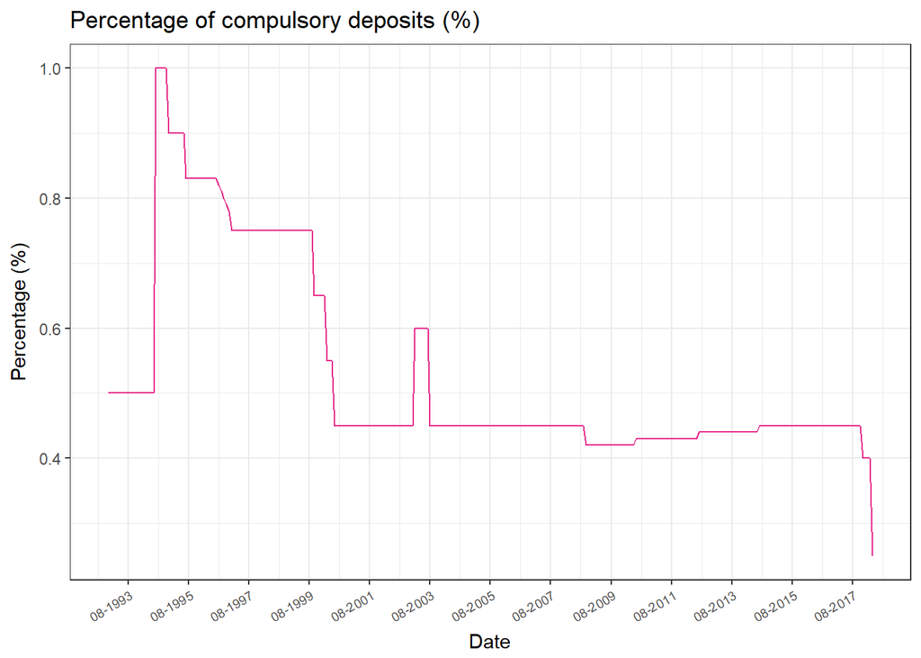

```r
p4
```

Now we are going to plot the compulsory deposits and the money multiplier together.

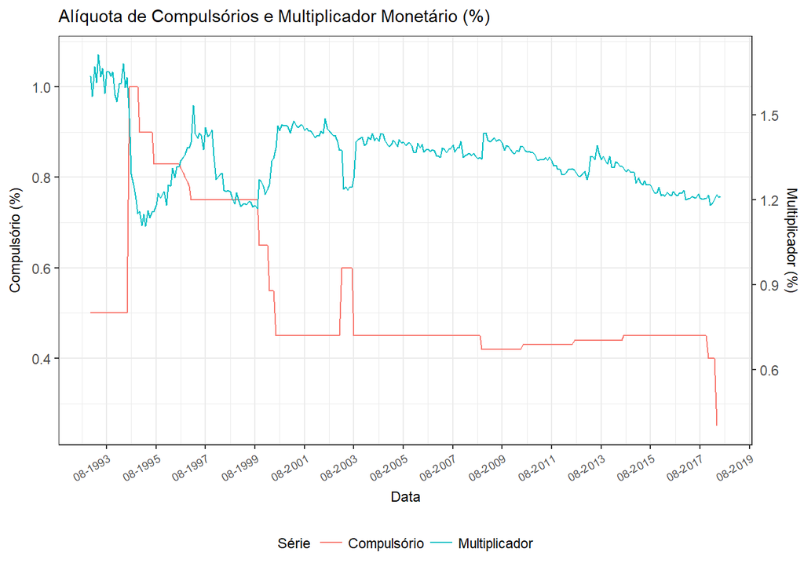

```r
df5 <- data.frame(seq(as.Date("1992-12-01"), length = length(window(mm, c(1992,12))), by = "1 month"), window(mm, c(1992,12)), compulsorio[1:(length(window(mm, c(1992,12)))),2])
names(df5) <- c("Data", "Multiplicador", "Compulsorio")

p5 <- ggplot(df5, aes(Data))+
        geom_line(aes(y = Compulsorio, colour = "Compulsório")) +
        geom_line(aes(y = Multiplicador*0.6, colour = "Multiplicador")) +
        scale_x_date(date_breaks = "24 months", name = "Data", labels = date_format("%m-%Y"))+
        scale_y_continuous(name = "Compulsório (%)", sec.axis = sec_axis(~.*1.6, name = "Multiplicador (%)"))+
        theme_bw() +
        theme(axis.text.x = element_text(angle=30, hjust = 1, size = 7), title = element_text(size = 9), legend.position = "bottom")+
        labs(title = "Alíquota de Compulsórios e Multiplicador Monetário (%)", colour = "Série")

p5
```

Obs: unlike Excel, in the `ggplot2` R package there is no option to [make two different vertical axis](https://stackoverflow.com/questions/3099219/plot-with-2-y-axes-one-y-axis-on-the-left-and-another-y-axis-on-the-right), but [some opstions](https://rpubs.com/MarkusLoew/226759) are available.

In the next graph we have the variables without any axis transformation.

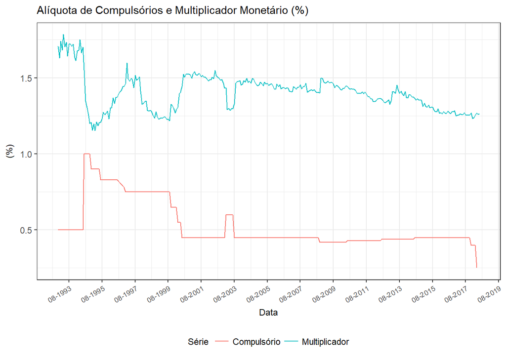

```r
p6 <- ggplot(df5, aes(Data))+
        geom_line(aes(y = Compulsorio, colour = "Compulsório")) +
        geom_line(aes(y = Multiplicador, colour = "Multiplicador")) +
        scale_x_date(date_breaks = "24 months", name = "Data", labels = date_format("%m-%Y"))+
        scale_y_continuous(name = "(%)")+
        theme_bw() +
        theme(axis.text.x = element_text(angle=30, hjust = 1, size = 7), title = element_text(size = 9), legend.position = "bottom")+
        labs(title = "Alíquota de Compulsórios e Multiplicador Monetário (%)", colour = "Série")

p6
```

# Estimating the money demand

## Getting the data

We are going to try to explain the money demand $m_t$ (here assumed equal to $M_1$) using GDP and interest rates. Due to time constraints, I’m going to take the first difference of the series in logs, to remove any trends. The following variables can be used:

- **Taxa de Juros - Selic** (*Interest Rate*)
  - **Beginning of the series:** July, 1986.
  - **End of the series:** April, 2018.
  - **Unity:** % monthly.
  - **Series number in SGS:** 4390.
  - **Source:** Brazil’s Central Bank - Open Market Operations Department (BCB-Demab).
- **Monthly GDP**
  - **Beginning of the series:** January, 1990.
  - **End of the series:** February, 2018.
  - **Unity:** Brazilian Real (R$) - millions.
  - **Series number in SGS:** 4380
  - **Source:** Brazil’s Central Bank - Economic Department (BCB-Depec).
  - **Obs**: O PIB mensal é um indicador mensal produzido pelo Banco Central do Brasil (BCB) para utilização no cálculo da relação entre agregados econômicos mensais (como dívida pública, saldo em transações correntes e saldo de crédito) e o PIB. Isto é feito porque o PIB, oficialmente calculado no Brasil pelo IBGE, é divulgado apenas em frequência trimestral, diferentemente de várias informações econômicas compiladas pelo Banco Central, como as citadas acima. Note que não se trata de cálculo do PIB a partir de informações primárias, mas apenas de uma estimativa que é feita via interpolação dos valores trimestrais já divulgados ou dos projetados.

I’m just going do download everything again to have all variables in the same dates.

```r
rm(list=ls()) # Clean everything

# Algumas variáveis auxiliares de datas, assim não precisamos alterar o código inteiro depois
# Eu recomendo sempre usar uma data de fim única, pois algumas variáveis demoram mais para ser atualizadas do que outras
inicio_82 <- "1982-01-01"
inicio_95 <- "1995-01-01" # Estou usando isso para cortar as séries posteriormente
inicio_96 <- "1996-01-01"
inicio_82b <- "1982-12-01"
fim       <- "2018-06-30"
ano <- as.numeric(substr(inicio_82, start = 1, stop = 4))
ano2 <- as.numeric(substr(inicio_82b, start = 1, stop = 4))
mes <- as.numeric(substr(inicio_82, start = 6, stop = 7))
mes2 <- as.numeric(substr(inicio_82b, start = 6, stop = 7))
dia <- as.numeric(substr(inicio_82, start = 9, stop = 10))

M1   <- BETS.get("1824", from = inicio_82, to = fim)
BM   <- BETS.get("1785", from = inicio_82, to = fim)
IPCA <- BETS.get("433",  from = inicio_82, to = fim)

# Agora preciso converter os valores de M1 e BM para reais
# Peguei aqui: http://diniznumismatica.blogspot.com.br/2017/10/converter-outros-padroes-monetarios-em.html
# Cruzeiro Novo (de 01/02/1967 até 28/02/1986)
# Faça a divisão por 1000^3 * 2750
M1_1 <- window(M1, c(1982,01), c(1986,02))/((1000^3)*2750)
BM_1 <- window(BM, c(1982,01), c(1986,02))/((1000^3)*2750)

# Cruzado (de 01/03/1986 até 31/01/1989)
# Faça a divisão por 1000^2 * 2750
M1_2 <- window(M1, c(1986,03), c(1989,01))/((1000^2)*2750)
BM_2 <- window(BM, c(1986,03), c(1989,01))/((1000^2)*2750)

# Cruzado Novo e Cruzeiro (01/02/1989 a 31/07/1993)
# Faça a divisão por 1000*2750
M1_3 <- window(M1, c(1989,02), c(1993,07))/(1000*2750)
BM_3 <- window(BM, c(1989,02), c(1993,07))/(1000*2750)

# Cruzeiro real (01/08/1993 a 30/06/1994)
# Faça a divisão por 2750
M1_4 <- window(M1, c(1993,08), c(1994,06))/(2750)
BM_4 <- window(BM, c(1993,08), c(1994,06))/(2750)

# Último pedaço - plano real
M1_5 <- window(M1, c(1994,07))
BM_5 <- window(BM, c(1994,07))

comb <- ts.union(M1_1, M1_2, M1_3, M1_4, M1_5)
M1_final <- pmin(comb[,1], comb[,2], comb[,3], comb[,4], comb[,5], na.rm = TRUE)

comb <- ts.union(BM_1, BM_2, BM_3, BM_4, BM_5)
BM_final <- pmin(comb[,1], comb[,2], comb[,3], comb[,4], comb[,5], na.rm = TRUE)

# Agora vou trabalhar com o deflator. Usei a metodologia do IPEA http://www.ipeadata.gov.br/iframe_transformacao.aspx?width=1474&height=701
ipca2 <- IPCA # Salvo em uma nova variável só pro caso de dar errado não ter que baixar os dados de novo
ipca2[1] <- 100 # Primeiro faço o primeiro valor ser a base e depois mudo de base porque eu aprendi assim

# Transforma em índice
for (i in 2:length(ipca2)){
  ipca2[i] <- round(ipca2[(i-1)]*(1+ipca2[(i)]/100),2)
}

# Média geométrica
for (i in 1:(length(ipca2)-1)){
  ipca2[i] <- sqrt(ipca2[i]*ipca2[(i+1)])
}

# Muda a base para o último valor
for (i in 1:length(ipca2)) {
  ipca2[i] <- tail(ipca2, n=1)/ipca2[i]
}

#ipca2 <- ts(ipca2,  start = c(ano, mes, dia), frequency = 12) # Converte para série temporal

# Deflaciona M1 e BM
M1_def <- M1_final * ipca2
BM_def <- BM_final * ipca2

PIBmensal <- BETS.get("4380", from = inicio_95, to = fim)
selic_4390 <- BETS.get("4390", from = inicio_95, to = fim)
# Transforms into anual rate
selic <- ((1+selic_4390/100)^(12)-1)*100

ipca2 <- window(ipca2, c(1995,01), c(2018,06))
ipca3 <- window(ipca2, c(1996,01), c(2018,06))
M1    <- window(M1_def, c(1995,01), c(2018,06))

PIBmensal <- PIBmensal * ipca2

# Calculating the acummulate inflation
ipca_raw  <- IPCA
ipca_raw <- ipca_raw[1:(length(ipca_raw)-1)]

ipca_acum <- ipca_raw/100 + 1
ipca <- vector()

final <- length(ipca_acum)
for (i in 12:final){
  ipca[(i-11)] <- (prod(ipca_acum[(i-11):i])-1)*100
}

ipca <- ts(ipca,  start = c(ano2, mes2, dia), frequency = 12) # Date format YYYY MM DD
ipca <- window(ipca, c(1995,01), c(2018,05))
M1   <- window(M1, c(1995,01), c(2018,05))
selic <- window(selic, c(1995,01), c(2018,05))
PIBmensal <- window(PIBmensal, c(1995,01), c(2018,05))
```

Making the plot of the “raw” variables together.

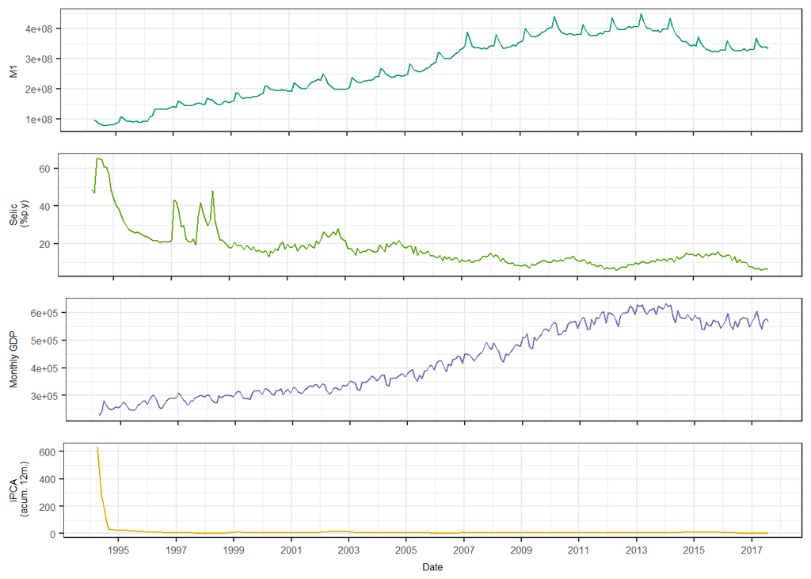

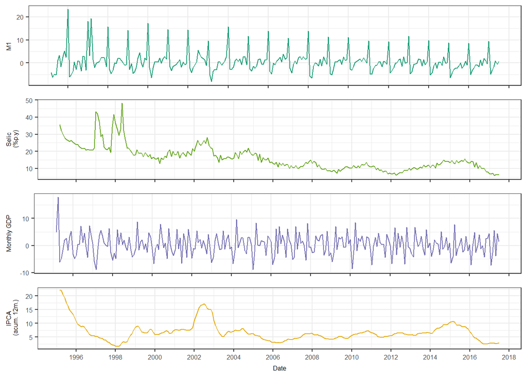

```r
PIBmensal_aux <- PIBmensal[-1]

PIBmensal_an <- vector()
for (i in 1:(length(PIBmensal)-1)) {
  PIBmensal_an[i] <- PIBmensal_aux[i]/head(PIBmensal, n=(length(PIBmensal)-12))[i]
}

PIBmensal_an <- ts((PIBmensal_an-1)*100,  start = c(1996, 01, 01), frequency = 12)

# M1
M1_aux <- M1[-1]

M1_an <- vector()
for (i in 1:(length(M1)-1)) {
  M1_an[i] <- M1_aux[i]/head(M1, n=(length(M1)-12))[i]
}

M1_an <- ts((M1_an-1)*100,  start = c(1996, 01, 01), frequency = 12)

M1_an <- window(M1_an, c(1996,01), c(2018,05))
PIBmensal_an <- window(PIBmensal_an, c(1996,01), c(2018,05))
selic <- window(selic, c(1996,01), c(2018,05))
ipca <- window(ipca, c(1996,01), c(2018,05))

# Plotting some nice graphs
## First, creates a data frame
df1 <- data.frame(seq(as.Date(inicio_96), length = length(ipca), by = "1 month"), M1_an, round(M1_an/10^7,2), selic, ipca, PIBmensal_an, round(PIBmensal_an/10^5),4)
names(df1) <- c("Data", "M1", "M1_arred", "selic", "IPCA", "PIBmensal", "PIBmensal_arred")
df2 <- melt(data = df1, id.vars = "Data")
cores <- brewer.pal(7, "Dark2")

## Individual Graphs
### M1
p1ori2 <- ggplot(df2[which(df2$variable == "M1"),], aes(Data, value, colour = variable)) +
        geom_line(alpha = 1, show.legend=F, colour = cores[1])+
        scale_y_continuous(name=expression(paste("M1", " \n"))) +
        scale_x_date(date_breaks = "24 months")+
        theme_bw()
p1ori2 <- p1ori2 + theme(axis.text.y = element_text(size=6), axis.text.x=element_blank(), axis.title.x = element_blank(), axis.title.y = element_text(size = 6))

### Selic
p2ori2 <- ggplot(df2[which(df2$variable == "selic"),], aes(Data, value, colour = variable)) +
        geom_line(alpha = 1, show.legend=F, colour = cores[5])+
        scale_y_continuous(name="Selic\n (%p.y)") +
        scale_x_date(date_breaks = "24 months")+
        theme_bw()
p2ori2 <- p2ori2 + theme(axis.text.y = element_text(size=6), axis.text.x=element_blank(), axis.title.x = element_blank(), axis.title.y = element_text(size = 6))

### GDP
p3ori2 <- ggplot(df2[which(df2$variable == "PIBmensal"),], aes(Data, value, colour = variable)) +
        geom_line(alpha = 1, show.legend=F, colour = cores[3])+
      scale_y_continuous(name=expression(paste("Monthly GDP", " \n"))) +
        scale_x_date(date_breaks = "24 months", name = "Date", labels = date_format("%Y"))+
        theme_bw()
p3ori2 <- p3ori2 + theme(axis.text.y = element_text(size=6), axis.text.x=element_blank(), axis.title.x = element_blank(), axis.title.y = element_text(size = 6))

## Price Index (IPCA)
p4ori2 <- ggplot(df2[which(df2$variable == "IPCA"),], aes(Data, value, colour = variable)) +
        geom_line(alpha = 1, show.legend=F, colour = cores[6])+
        scale_y_continuous(name="IPCA\n (acum. 12m.)") +
        scale_x_date(date_breaks = "24 months", name = "Date", labels = date_format("%Y"))+
        theme_bw()
p4ori2 <- p4ori2 + theme(axis.text.y = element_text(size=6), axis.text.x=element_text(size=6), axis.title.x = element_text(size=6), axis.title.y = element_text(size = 6))

grid.arrange(p1ori2, p2ori2, p3ori2, p4ori2, ncol=1, nrow = 4)
```

M1 still presents a cyclical component. I’m going to use X-13ARIMA in the authomatic setup.

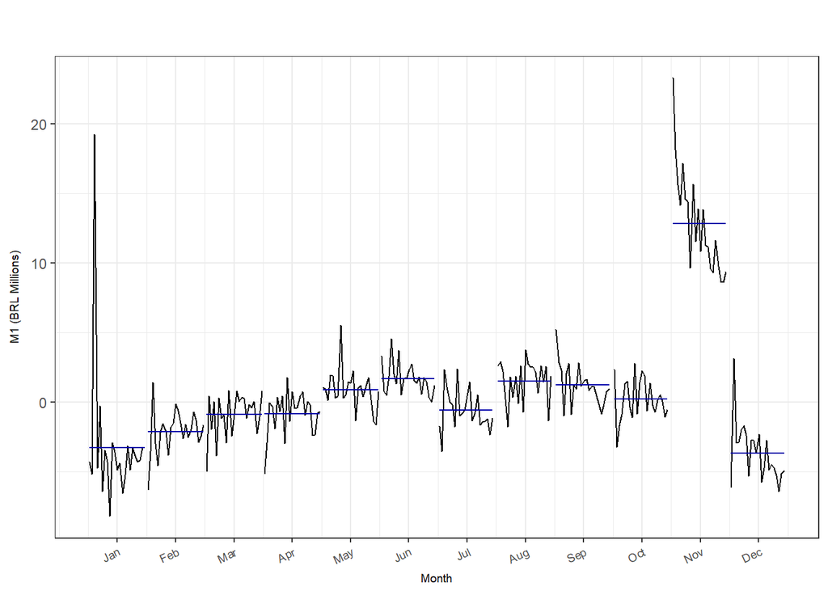

```r
meses <- ggmonthplot(M1_an) +
  theme_bw() +
  #scale_y_continuous(name = "Capital-Labor Ratio (% - average)") +
  scale_y_continuous(name = "M1 (BRL Millions)") +
  labs(title = "", x = "Month", subtitle = "")+
  theme(axis.title = element_text(size=7), axis.text.x = element_text(angle=25, hjust = 1, size = 7))
  #labs(title = "Média diária e mensal da razão capital-trabalho", x = "Mês", subtitle = "Nenhuma transformação")
  #labs(title = "Daily and monthly averages of Capital-Labor ratio", x = "Month", subtitle = "No data transformation")
meses
```

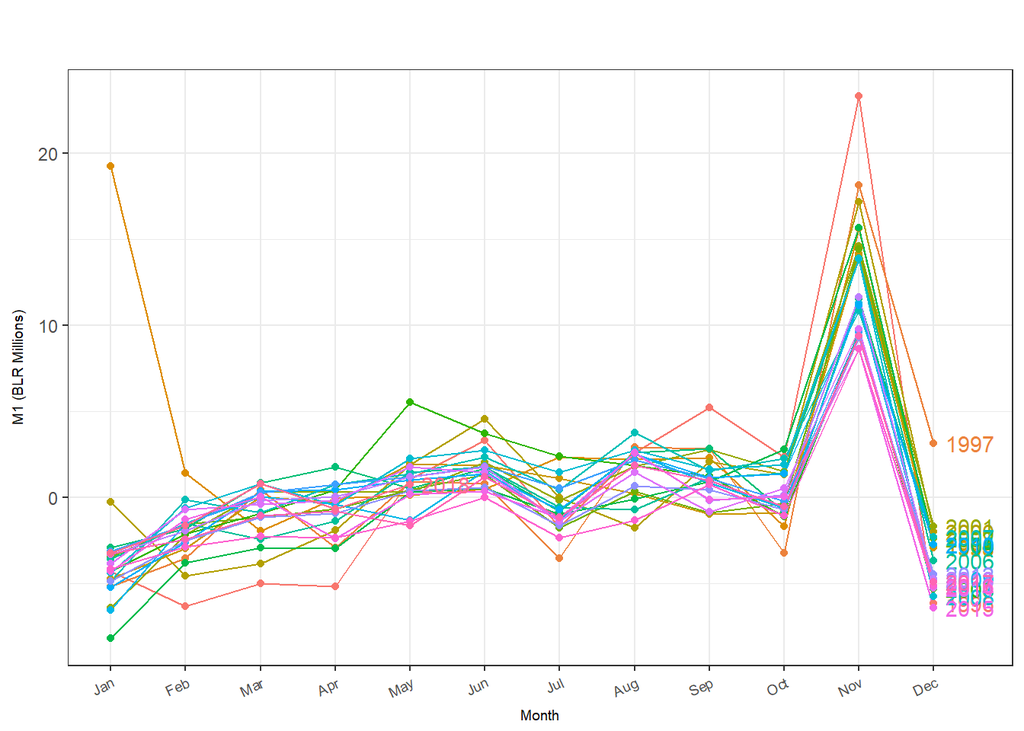

```r
# Seasonplot has the averages for month, each line represents a year
season <- ggseasonplot(M1_an, year.labels = TRUE) +
  geom_point() +
  theme_bw() +
  scale_y_continuous(name = "M1 (BLR Millions)") +
  labs(title = "", x = "Month", subtitle = "")+
  theme(axis.title = element_text(size=7), axis.text.x = element_text(angle=25, hjust = 1, size = 7))
season
```

```r
m <- seas(x = M1_an, transform.function = "none", regression.aictest = NULL)

qs(m)
```

```
##                     qs   p-val
## qsori        362.45991 0.00000
## qsorievadj   436.66368 0.00000
## qsrsd          0.00000 1.00000
## qssadj         0.00000 1.00000
## qssadjevadj    0.00000 1.00000
## qsirr          0.00000 1.00000
## qsirrevadj     0.00000 1.00000
## qssori       150.91471 0.00000
## qssorievadj  150.91471 0.00000
## qssrsd         4.55399 0.10259
## qsssadj        0.00233 0.99884
## qsssadjevadj   0.00233 0.99884
## qssirr         0.00000 1.00000
## qssirrevadj    0.00000 1.00000
```

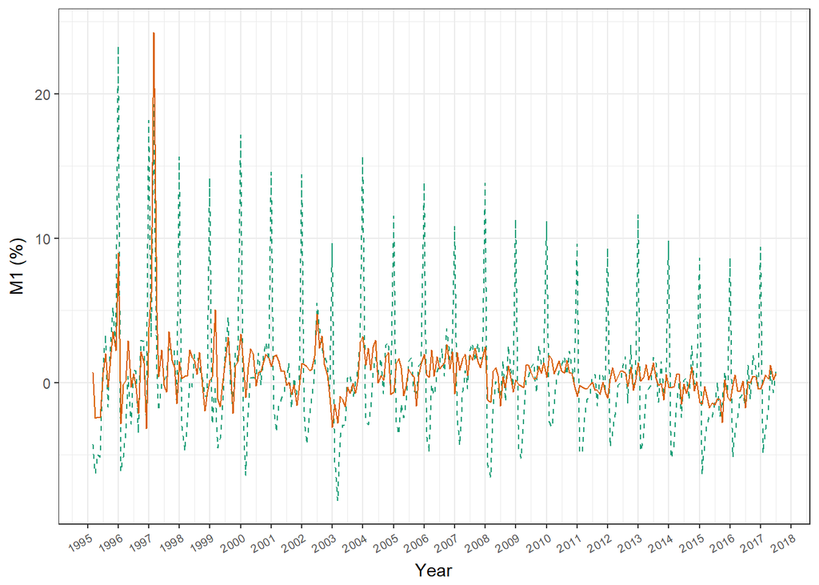

```r
# Click here to see the how the qs statistics is calculated: https://stats.stackexchange.com/questions/148573/the-results-and-specifics-from-the-qs-function-in-r
# The first 7 results are related to the whole series, the last 7 comprehends only the last 8 years
# qsori is the original series
# qsorievadj is the original series corrected for extreme values
# qsrsd is the residual's series of the ARIMA model
# qssadj is the series with seasonal adjustment
# qssadjevadj is the series with seasonal adjustment corrected for extreme values
# qsirr is the series of the irregular component
# qsirrevadj is the series of the irregular component corrected for extreme values
# by the output, we can conclude that there is no evidence of seasonal components in the adjusted series, the residuals and the irregular component, even when we look just the last 8 years.

M1_adj <- final(m)
df1$M1_adj <- M1_adj
df2 <- melt(data = df1, id.vars = "Data")

p1ori3 <- ggplot(df2[which(df2$variable == "M1_adj"),], aes(Data, value, colour = variable)) +
        geom_line(alpha = 1, show.legend=F, colour = cores[1])+
        scale_y_continuous(name=expression(paste("M1", " \n"))) +
        scale_x_date(date_breaks = "24 months")+
        theme_bw()
p1ori3 <- p1ori3 + theme(axis.text.y = element_text(size=6), axis.text.x=element_blank(), axis.title.x = element_blank(), axis.title.y = element_text(size = 6))

df3 <- data.frame(df1$Data, M1_adj, M1_an)
names(df3) <- c("Data", "M1_adj", "M1_an")

p1 <- ggplot(df3, aes(Data)) +
  geom_line(aes(y = M1_an, colour = "A. Var."), linetype = "dashed") +
  geom_line(aes(y = M1_adj, colour = "After X-13")) +
  scale_x_date(date_breaks = "12 months", name = "Year", labels = date_format("%Y"))+
  scale_y_continuous(name = "M1 (%)")+
  labs(color="Série") +
  scale_colour_manual("Variable", breaks = c("Original", "Filtered"), values = c(cores[1], cores[2]))+
  theme_bw() + theme(axis.text.x = element_text(angle=30, hjust = 1, size = 7), legend.position = "top")

p1
```

Descriptives

|  | selic | ipca | PIBmensal_an | M1_adj |
| --- | --- | --- | --- | --- |
| Observations | 269.0000 | 269.0000 | 269.0000 | 269.0000 |
| Mínimum | 5.7881 | 1.6456 | -8.8946 | -3.1595 |
| 1o quartile | 10.6906 | 4.7359 | -1.8214 | -0.3167 |
| Mean | 15.9856 | 6.7827 | 0.4227 | 0.6084 |
| Median | 14.1640 | 6.2531 | 0.2828 | 0.4712 |
| 3o quartile | 19.5618 | 7.6616 | 2.9814 | 1.3723 |
| Maximum | 48.1553 | 21.9876 | 17.8146 | 24.2746 |
| St. Dev. | 7.1856 | 3.4388 | 3.9031 | 2.0897 |

```
## Selic series is integrated of order 0 , IPCA is integrated of order 0 , annual variation of the monthly GDP is integrated of order 0 and M1 is integrated of order 0 . The test used was the Augmented Dickey-Fuller with alpha = 0.1.
```

Since all variables can be considered stationary, we don’t need to worry about cointegration, VECM or stuff like that.

## Estimating a classical VAR

```r
# Number of lags
library(vars)
lag_maximo <- VARselect(var1, lag.max = 4)

tabelinha <- matrix(NA, ncol = 4, nrow = 1)
colnames(tabelinha) <- names(lag_maximo$selection)
tabelinha[1,] <- lag_maximo$selection

tabelinha <- data.frame(tabelinha)

kable(tabelinha, "html") %>%
  kable_styling(bootstrap_options = c("striped", "hover"))
```

| AIC.n. | HQ.n. | SC.n. | FPE.n. |
| --- | --- | --- | --- |
| 3 | 3 | 2 | 3 |

```r
results2 <- VAR(var1, lag.max = 3, ic = "AIC", type = "const")
```

## Estimating a Bayesian VAR

I used the package `MTS` with the `BVAR` function.

```r
library(MTS, quietly = T)
p. = 3
C=0.01*diag(rep(1, ncol(var1)*p.+1))
V0=diag(rep(1,ncol(var1)))
var_b <- BVAR(var1,p=3,C,V0)
```

```
## Bayesian estimate:
##                 Est        s.e.     t-ratio
##  [1,]  0.4534930473 0.474674470  0.95537695
##  [2,]  0.8448789634 0.060483538 13.96874239
##  [3,]  0.7971688969 0.417574259  1.90904702
##  [4,]  0.1883938631 0.044467575  4.23665697
##  [5,] -0.1858740238 0.085896296 -2.16393526
##  [6,]  0.0270006481 0.078868881  0.34234856
##  [7,] -1.2016665473 0.747698346 -1.60715421
##  [8,] -0.0065910627 0.043210588 -0.15253351
##  [9,]  0.1028852692 0.089350591  1.15147832
## [10,]  0.0854547088 0.061313112  1.39374280
## [11,]  0.4327919639 0.404679809  1.06946765
## [12,]  0.0779893810 0.043333230  1.79975925
## [13,] -0.1502071558 0.084610083 -1.77528671
```

[output cut: 45 more lines]

### Comparing classical and bayesian estimates for the whole model

To understand the table: CVAR are the classical estimates, BVAR the bayesian. First two columns refer to `selic`, then the next two refer to `ipca`, `GDP` and finally the `M1` equations.

```r
# Comparing the classical and the bayesian estimate
tabela <- matrix(NA, ncol = 3, nrow = length(results2$varresult$selic$coefficients)+1)
tabela[1,] <- c("Coef", "CVAR", "BVAR")
tabela[,1] <- c("Coef", "const", "selic_1", "ipca_1", "PIB_1", "M1_1", "selic_2", "ipca_2", "PIB_2", "M1_2", "selic_3", "ipca_3", "PIB_3", "M1_3")

# SELIC
tabela[2:(length(results2$varresult$selic$coefficients)+1),2] <- round(c(tail(results2$varresult$selic$coefficients,1), head(results2$varresult$selic$coefficients, length(results2$varresult$selic$coefficients)-1)),3)

const1 <- 0.4534930473

tabela[2:(length(results2$varresult$selic$coefficients)+1),3] <- round(c(const1, var_b$Phi[1,]), 2)
tab_selic <- tabela

# IPCA
tabela[2:(length(results2$varresult$ipca$coefficients)+1),2] <- round(c(tail(results2$varresult$ipca$coefficients,1), head(results2$varresult$ipca$coefficients, length(results2$varresult$ipca$coefficients)-1)),3)

const2 <- 0.2002184153

tabela[2:(length(results2$varresult$ipca$coefficients)+1),3] <- round(c(const1, var_b$Phi[2,]), 2)
tab_ipca <- tabela

# PIB
tabela[2:(length(results2$varresult$PIBmensal_an$coefficients)+1),2] <- round(c(tail(results2$varresult$PIBmensal_an$coefficients,1), head(results2$varresult$PIBmensal_an$coefficients, length(results2$varresult$PIBmensal_an$coefficients)-1)),3)

const3 <- 1.1259634830

tabela[2:(length(results2$varresult$PIBmensal_an$coefficients)+1),3] <- round(c(const1, var_b$Phi[3,]), 2)
tab_pib <- tabela

# M1
tabela[2:(length(results2$varresult$M1_adj$coefficients)+1),2] <- round(c(tail(results2$varresult$M1_adj$coefficients,1), head(results2$varresult$M1_adj$coefficients, length(results2$varresult$M1_adj$coefficients)-1)),3)

const4 <- -0.2158652580

tabela[2:(length(results2$varresult$M1_adj$coefficients)+1),3] <- round(c(const1, var_b$Phi[4,]), 2)
tab_M1 <- tabela

####

tabelona <- data.frame(tab_selic, tab_ipca[,2:3], tab_pib[,2:3], tab_M1[,2:3])

names(tabelona) <- c("Coef", rep(c("CVAR", "BVAR"), ncol(var1)))
tabelona <- tabelona[-1,]



kable(tabelona, "html") %>%
  kable_styling(bootstrap_options = c("striped", "hover"))
```

|  | Coef | CVAR | BVAR | CVAR | BVAR | CVAR | BVAR | CVAR | BVAR |
| --- | --- | --- | --- | --- | --- | --- | --- | --- | --- |
| 2 | const | 0.453 | 0.45 | 0.2 | 0.45 | 1.126 | 0.45 | -0.216 | 0.45 |
| 3 | selic_1 | 0.845 | 0.84 | -0.002 | 0 | -0.097 | -0.1 | 0.157 | 0.16 |
| 4 | ipca_1 | 0.798 | 0.8 | 1.677 | 1.68 | 0.657 | 0.66 | -0.252 | -0.25 |
| 5 | PIB_1 | 0.188 | 0.19 | -0.006 | -0.01 | -0.165 | -0.17 | 0.002 | 0 |
| 6 | M1_1 | -0.186 | -0.19 | 0.001 | 0 | 0.098 | 0.1 | 0.23 | 0.23 |
| 7 | selic_2 | 0.027 | 0.03 | -0.005 | -0.01 | 0.029 | 0.03 | 0.146 | 0.15 |
| 8 | ipca_2 | -1.203 | -1.2 | -0.726 | -0.73 | -0.994 | -0.99 | 0.573 | 0.57 |
| 9 | PIB_2 | -0.007 | -0.01 | 0.002 | 0 | -0.225 | -0.23 | 0.028 | 0.03 |
| 10 | M1_2 | 0.103 | 0.1 | -0.004 | 0 | -0.068 | -0.07 | 0.086 | 0.09 |
| 11 | selic_3 | 0.085 | 0.09 | 0.009 | 0.01 | 0.03 | 0.03 | -0.238 | -0.24 |
| 12 | ipca_3 | 0.434 | 0.43 | 0.015 | 0.01 | 0.333 | 0.33 | -0.368 | -0.37 |
| 13 | PIB_3 | 0.078 | 0.08 | -0.005 | 0 | -0.168 | -0.17 | -0.012 | -0.01 |
| 14 | M1_3 | -0.15 | -0.15 | -0.013 | -0.01 | 0.13 | 0.13 | -0.03 | -0.03 |

## Looking into the residuals from the classical model

```r
resid_selic_var <- resid(results2$varresult$selic)
resid_ipca_var <- resid(results2$varresult$ipca)
resid_PIBmensal_var <- resid(results2$varresult$PIBmensal_an)
resid_M1_var <- resid(results2$varresult$M1_adj)

df_resid_var <- data.frame(seq(as.Date(inicio_95)+3, length = length(ipca)-3, by = "1 month"), resid_selic_var, resid_ipca_var, resid_PIBmensal_var, resid_M1_var)

names(df_resid_var) <- c("Date", "Selic", "IPCA", "GDP", "M1")
df2 <- melt(data = df_resid_var, id.vars = "Date")

## Individual Graphs
### M1
p1ori <- ggplot(df2[which(df2$variable == "M1"),], aes(Date, value, colour = variable)) +
        geom_point(alpha = 1, show.legend=F, colour = cores[1])+
        scale_y_continuous(name=expression(paste("M1", " \n"))) +
        scale_x_date(date_breaks = "24 months", name = "Date", labels = date_format("%Y"))+
        theme_bw()
p1ori <- p1ori + theme(axis.text.y = element_text(size=6), axis.text.x=element_text(angle=30, hjust = 0.5, size=6), axis.title.x = element_blank(), axis.title.y = element_text(size = 6))

### Selic
p2ori <- ggplot(df2[which(df2$variable == "Selic"),], aes(Date, value, colour = variable)) +
        geom_point(alpha = 1, show.legend=F, colour = cores[5])+
        scale_y_continuous(name="Selic\n (%p.y)") +
        scale_x_date(date_breaks = "24 months", name = "Date", labels = date_format("%Y"))+
        theme_bw()
p2ori <- p2ori + theme(axis.text.y = element_text(size=6), axis.text.x=element_text(angle=30, hjust = 0.5, size=6), axis.title.x = element_blank(), axis.title.y = element_text(size = 6))

### GDP
p3ori <- ggplot(df2[which(df2$variable == "GDP"),], aes(Date, value, colour = variable)) +
        geom_point(alpha = 1, show.legend=F, colour = cores[3])+
      scale_y_continuous(name=expression(paste("Monthly GDP", " \n"))) +
        scale_x_date(date_breaks = "24 months", name = "Date", labels = date_format("%Y"))+
        theme_bw()
p3ori <- p3ori + theme(axis.text.y = element_text(size=6), axis.text.x=element_text(angle=30, hjust = 0.5, size=6), axis.title.x = element_blank(), axis.title.y = element_text(size = 6))

## Price Index (IPCA)
p4ori <- ggplot(df2[which(df2$variable == "IPCA"),], aes(Date, value, colour = variable)) +
        geom_point(alpha = 1, show.legend=F, colour = cores[6])+
        scale_y_continuous(name="IPCA\n (acum. 12m.)") +
        scale_x_date(date_breaks = "24 months", name = "Date", labels = date_format("%Y"))+
        theme_bw()
p4ori <- p4ori + theme(axis.text.y = element_text(size=6), axis.text.x=element_text(angle=30, hjust = 0.5, size=6), axis.title.x = element_text(size=6), axis.title.y = element_text(size = 6))

#grid.arrange(p1ori, p2ori, p3ori, p4ori, ncol=2, nrow = 2)
```

Other diagnostics

```r
normality.test(results2)
```

```
## $JB
##
##  JB-Test (multivariate)
##
## data:  Residuals of VAR object results2
## Chi-squared = 13775, df = 8, p-value < 2.2e-16
##
##
## $Skewness
##
##  Skewness only (multivariate)
##
## data:  Residuals of VAR object results2
## Chi-squared = 747.04, df = 4, p-value < 2.2e-16
##
##
## $Kurtosis
##
##  Kurtosis only (multivariate)
##
## data:  Residuals of VAR object results2
## Chi-squared = 13028, df = 4, p-value < 2.2e-16
```

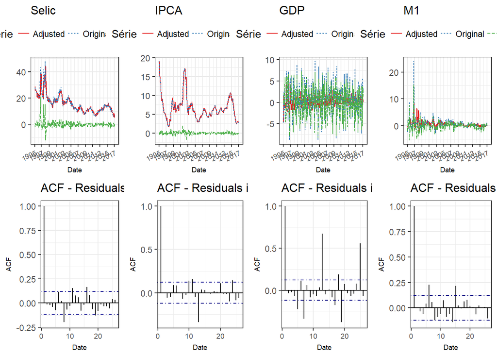

```r
# SELIC
df1 <- data.frame(seq(as.Date(inicio_95)+3, length = length(ipca)-3, by = "1 month"), results2$varresult$selic$fitted.values, results2$y[4:nrow(var1),1], results2$varresult$selic$residuals)
names(df1) <- c("Date", "Adjusted", "Original", "Residual")

df2 <- melt(data = df1, id.vars = "Date")

p1 <- ggplot(df2, aes(Date, value, colour = variable))+
  geom_line(alpha = 1, aes(linetype = variable))+
  labs(title="Selic", y = "", x = "Date", color = "Série") +
  scale_colour_brewer(palette = "Set1")+
  scale_x_date(date_breaks = "2 year", name = "Date", labels = date_format("%Y"))+
  theme_bw()

p1 <- p1 + labs(linetype = "Série")
p1 <- p1 + labs(colour = "Série")
p1 <- p1 + theme(legend.position = "top", legend.key.size = unit(.5, "cm"), axis.text.x = element_text(angle = 25, hjust = 1, size = 7), axis.title.y = element_text(size = 7), axis.title.x = element_text(size = 7), plot.title = element_text(size = 12))

bacf <- acf(results2$varresult$selic$residuals, plot = FALSE, lag.max = 25)
bacfdf <- with(bacf, data.frame(1:26, acf))
names(bacfdf) <- c("lag", "acf")
conf.level <- 0.95
ciline <- qnorm((1 - conf.level)/2)/sqrt(length(results2$varresult$selic$residuals))

acf_selic <- ggplot(data = bacfdf, mapping = aes(x = lag, y = acf)) +
       geom_hline(aes(yintercept = 0)) +
       geom_segment(mapping = aes(xend = lag, yend = 0))+
       labs(title="ACF - Residuals in the Selic equation", y = "ACF", x = "Date") +
       geom_hline(aes(yintercept = ciline), linetype = 4, color = 'darkblue') +
       geom_hline(aes(yintercept = -ciline), linetype = 4, color = 'darkblue')+
       theme_bw()+
       theme(axis.text.x = element_text(size = 7), axis.title.y = element_text(size = 7), axis.title.x = element_text(size = 7), plot.title = element_text(size = 12))

# IPCA
df1 <- data.frame(seq(as.Date(inicio_95)+3, length = length(ipca)-3, by = "1 month"), results2$varresult$ipca$fitted.values, results2$y[4:nrow(var1),2], results2$varresult$ipca$residuals)
names(df1) <- c("Date", "Adjusted", "Original", "Residual")

df2 <- melt(data = df1, id.vars = "Date")

p2 <- ggplot(df2, aes(Date, value, colour = variable))+
  geom_line(alpha = 1, aes(linetype = variable))+
  labs(title="IPCA", y = "", x = "Date", color = "Série") +
  scale_colour_brewer(palette = "Set1")+
  scale_x_date(date_breaks = "2 year", name = "Date", labels = date_format("%Y"))+
  theme_bw()

p2 <- p2 + labs(linetype = "Série")
p2 <- p2 + labs(colour = "Série")
p2 <- p2 + theme(legend.position = "top", legend.key.size = unit(.5, "cm"), axis.text.x = element_text(angle = 25, hjust = 1, size = 7), axis.title.y = element_text(size = 7), axis.title.x = element_text(size = 7), plot.title = element_text(size = 12))

bacf <- acf(results2$varresult$ipca$residuals, plot = FALSE, lag.max = 25)
bacfdf <- with(bacf, data.frame(1:26, acf))
names(bacfdf) <- c("lag", "acf")
conf.level <- 0.95
ciline <- qnorm((1 - conf.level)/2)/sqrt(length(results2$varresult$ipca$residuals))

acf_ipca <- ggplot(data = bacfdf, mapping = aes(x = lag, y = acf)) +
       geom_hline(aes(yintercept = 0)) +
       geom_segment(mapping = aes(xend = lag, yend = 0))+
       labs(title="ACF - Residuals in IPCA equation", y = "ACF", x = "Date") +
       geom_hline(aes(yintercept = ciline), linetype = 4, color = 'darkblue') +
       geom_hline(aes(yintercept = -ciline), linetype = 4, color = 'darkblue')+
       theme_bw()+
       theme(axis.text.x = element_text(size = 7), axis.title.y = element_text(size = 7), axis.title.x = element_text(size = 7), plot.title = element_text(size = 12))


# PIB
df1 <- data.frame(seq(as.Date(inicio_95)+3, length = length(ipca)-3, by = "1 month"), results2$varresult$PIBmensal_an$fitted.values, results2$y[4:nrow(var1),3], results2$varresult$PIBmensal_an$residuals)
names(df1) <- c("Date", "Adjusted", "Original", "Residual")

df2 <- melt(data = df1, id.vars = "Date")

p3 <- ggplot(df2, aes(Date, value, colour = variable))+
  geom_line(alpha = 1, aes(linetype = variable))+
  labs(title="GDP", y = "", x = "Date", color = "Série") +
  scale_colour_brewer(palette = "Set1")+
  scale_x_date(date_breaks = "2 year", name = "Date", labels = date_format("%Y"))+
  theme_bw()

p3 <- p3 + labs(linetype = "Série")
p3 <- p3 + labs(colour = "Série")
p3 <- p3 + theme(legend.position = "top", legend.key.size = unit(.5, "cm"), axis.text.x = element_text(angle = 25, hjust = 1, size = 7), axis.title.y = element_text(size = 7), axis.title.x = element_text(size = 7), plot.title = element_text(size = 12))

bacf <- acf(results2$varresult$PIBmensal_an$residuals, plot = FALSE, lag.max = 25)
bacfdf <- with(bacf, data.frame(1:26, acf))
names(bacfdf) <- c("lag", "acf")
conf.level <- 0.95
ciline <- qnorm((1 - conf.level)/2)/sqrt(length(results2$varresult$PIBmensal_an$residuals))

acf_pib <- ggplot(data = bacfdf, mapping = aes(x = lag, y = acf)) +
       geom_hline(aes(yintercept = 0)) +
       geom_segment(mapping = aes(xend = lag, yend = 0))+
       labs(title="ACF - Residuals in GDP equation", y = "ACF", x = "Date") +
       geom_hline(aes(yintercept = ciline), linetype = 4, color = 'darkblue') +
       geom_hline(aes(yintercept = -ciline), linetype = 4, color = 'darkblue')+
       theme_bw()+
       theme(axis.text.x = element_text(size = 7), axis.title.y = element_text(size = 7), axis.title.x = element_text(size = 7), plot.title = element_text(size = 12))

# M1
# PIB
df1 <- data.frame(seq(as.Date(inicio_95)+3, length = length(ipca)-3, by = "1 month"), results2$varresult$M1_adj$fitted.values, results2$y[4:nrow(var1),4], results2$varresult$M1_adj$residuals)
names(df1) <- c("Date", "Adjusted", "Original", "Residual")

df2 <- melt(data = df1, id.vars = "Date")

p4 <- ggplot(df2, aes(Date, value, colour = variable))+
  geom_line(alpha = 1, aes(linetype = variable))+
  labs(title="M1", y = "", x = "Date", color = "Série") +
  scale_colour_brewer(palette = "Set1")+
  scale_x_date(date_breaks = "2 year", name = "Date", labels = date_format("%Y"))+
  theme_bw()

p4 <- p4 + labs(linetype = "Série")
p4 <- p4 + labs(colour = "Série")
p4 <- p4 + theme(legend.position = "top", legend.key.size = unit(.5, "cm"), axis.text.x = element_text(angle = 25, hjust = 1, size = 7), axis.title.y = element_text(size = 7), axis.title.x = element_text(size = 7), plot.title = element_text(size = 12))

bacf <- acf(results2$varresult$M1_adj$residuals, plot = FALSE, lag.max = 25)
bacfdf <- with(bacf, data.frame(1:26, acf))
names(bacfdf) <- c("lag", "acf")
conf.level <- 0.95
ciline <- qnorm((1 - conf.level)/2)/sqrt(length(results2$varresult$M1_adj$residuals))

acf_M1 <- ggplot(data = bacfdf, mapping = aes(x = lag, y = acf)) +
       geom_hline(aes(yintercept = 0)) +
       geom_segment(mapping = aes(xend = lag, yend = 0))+
       labs(title="ACF - Residuals in M1 equation", y = "ACF", x = "Date") +
       geom_hline(aes(yintercept = ciline), linetype = 4, color = 'darkblue') +
       geom_hline(aes(yintercept = -ciline), linetype = 4, color = 'darkblue')+
       theme_bw()+
       theme(axis.text.x = element_text(size = 7), axis.title.y = element_text(size = 7), axis.title.x = element_text(size = 7), plot.title = element_text(size = 12))

grid.arrange(p1, p2, p3, p4, acf_selic, acf_ipca, acf_pib, acf_M1, nrow = 2, ncol = 4)
```

## Looking into the residuals from the bayesian model

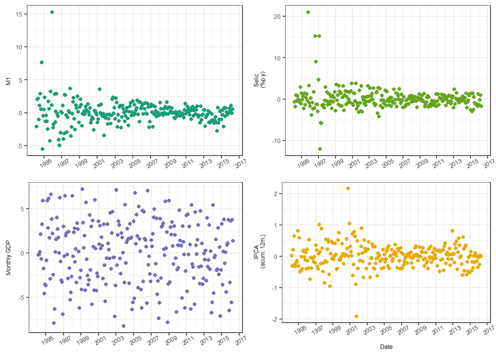

```r
resid_selic_bvar <- var_b$residuals[,1]
resid_ipca_bvar <- var_b$residuals[,2]
resid_PIBmensal_bvar <- var_b$residuals[,3]
resid_M1_bvar <- var_b$residuals[,4]

df_resid_bvar <- data.frame(seq(as.Date(inicio_95)+3, length = length(ipca)-3, by = "1 month"), resid_selic_bvar, resid_ipca_bvar, resid_PIBmensal_bvar, resid_M1_bvar)

names(df_resid_bvar) <- c("Date", "Selic", "IPCA", "GDP", "M1")
df2 <- melt(data = df_resid_bvar, id.vars = "Date")

## Individual Graphs
### M1
p1ori2 <- ggplot(df2[which(df2$variable == "M1"),], aes(Date, value, colour = variable)) +
        geom_point(alpha = 1, show.legend=F, colour = cores[1])+
        scale_y_continuous(name=expression(paste("M1", " \n"))) +
        scale_x_date(date_breaks = "24 months", name = "Date", labels = date_format("%Y"))+
        theme_bw()
p1ori2 <- p1ori2 + theme(axis.text.y = element_text(size=6), axis.text.x=element_text(angle=30, hjust = 0.5, size=6), axis.title.x = element_blank(), axis.title.y = element_text(size = 6))

### Selic
p2ori2 <- ggplot(df2[which(df2$variable == "Selic"),], aes(Date, value, colour = variable)) +
        geom_point(alpha = 1, show.legend=F, colour = cores[5])+
        scale_y_continuous(name="Selic\n (%p.y)") +
        scale_x_date(date_breaks = "24 months", name = "Date", labels = date_format("%Y"))+
        theme_bw()
p2ori2 <- p2ori2 + theme(axis.text.y = element_text(size=6), axis.text.x=element_text(angle=30, hjust = 0.5, size=6), axis.title.x = element_blank(), axis.title.y = element_text(size = 6))

### GDP
p3ori2 <- ggplot(df2[which(df2$variable == "GDP"),], aes(Date, value, colour = variable)) +
        geom_point(alpha = 1, show.legend=F, colour = cores[3])+
      scale_y_continuous(name=expression(paste("Monthly GDP", " \n"))) +
        scale_x_date(date_breaks = "24 months", name = "Date", labels = date_format("%Y"))+
        theme_bw()
p3ori2 <- p3ori2 + theme(axis.text.y = element_text(size=6), axis.text.x=element_text(angle=30, hjust = 0.5, size=6), axis.title.x = element_blank(), axis.title.y = element_text(size = 6))

## Price Index (IPCA)
p4ori2 <- ggplot(df2[which(df2$variable == "IPCA"),], aes(Date, value, colour = variable)) +
        geom_point(alpha = 1, show.legend=F, colour = cores[6])+
        scale_y_continuous(name="IPCA\n (acum. 12m.)") +
        scale_x_date(date_breaks = "24 months", name = "Date", labels = date_format("%Y"))+
        theme_bw()
p4ori2 <- p4ori2 + theme(axis.text.y = element_text(size=6), axis.text.x=element_text(angle=30, hjust = 0.5, size=6), axis.title.x = element_text(size=6), axis.title.y = element_text(size = 6))

grid.arrange(p1ori2, p2ori2, p3ori2, p4ori2, ncol=2, nrow = 2)
```

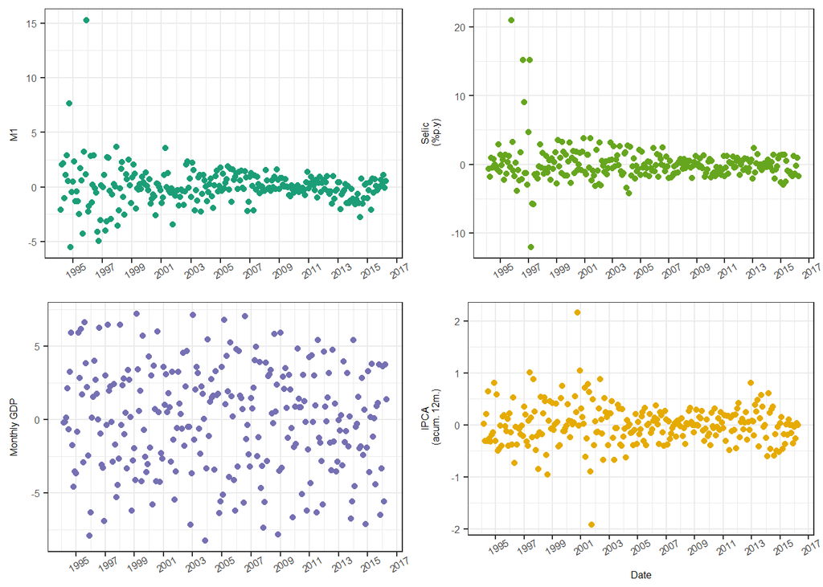

```r
grid.arrange(p1ori, p2ori, p3ori, p4ori, ncol=2, nrow = 2)
```

Other diagnostics: in order to calculate the predicted values, I could use the posterior means and multiply by the X matrix (the lagged values would be needed). I don’t have time to think about this now, so maybe future Aisha can do something about this.